# Prosper Loan Analysis using R

#### By Xia Chen, 2018-11-01, Toronto

# 1.Introduction

> Prosper is America's first marketplace peer-to-peer lending platform, with over $12 billion in funded loans. This data set contains 113,937 loans with 81 variables on each loan, including loan amount, borrower rate (or interest rate), current loan status, borrower income, borrower employment status, borrower credit score, etc.

> In this project, an Exploratory Data Analysis (EDA) for the Prosper loan data set from 2005-2014 was conducted, in order to dig out some inspiring and valuable insights about the features that can affect the loan status.

#### The outline of this project is:

> 1. Introduction
> 2. Exploratory Data Analysis 2.1 Univariate Plots Section 2.2 Univariate Analysis 2.3 Bivariate Plots Section 2.4 Bivariate Analysis 2.5 Multivariate Plots Section 2.6 Multivariate Analysis
> 3. Final Plots and Summary
> 4. Reflection

## 1.1 Install R packages

> In this analysis, I used 9 packages for data manipulation, data visulization and correlation analysis. The name are below: ggplot2, date, dplyr, gridExtra, scales, choroplethrMaps, chroplethr, GGally, knitr.

## 1.2 Load data

> The Prosper loan data contains 113,937 loans that were issued through 2005-2014, with 81 variables for each loan. The key feature is the loan status which could help investors estimate the default risk of borrowers. The interesting features that might affect the loan status could from numerical variables, including borrower rate,monthly income,loan amount, credit score, term of the loan, total prospers loans. The fetures could also from and categorical variables, including employment status, loan purpose, home ownership, borrower state.

# 2. Exploratory Data Analysis

# 2.1 Univariate Plots Section

> In this section, I want to start exploring the data by reviewing some basic values and descriptive statistics. The fetures that I am interested to investigate are below:

### 2.1.1 Loan term

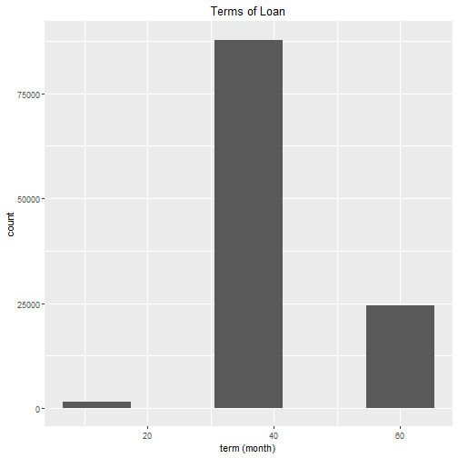

> The time length of the laon might affect the borrowers' ability to pay off the bill. The graph below showes the number of 36-month loans is much greater than 60-month and 12-month loans.

### 2.1.2 Loan Status

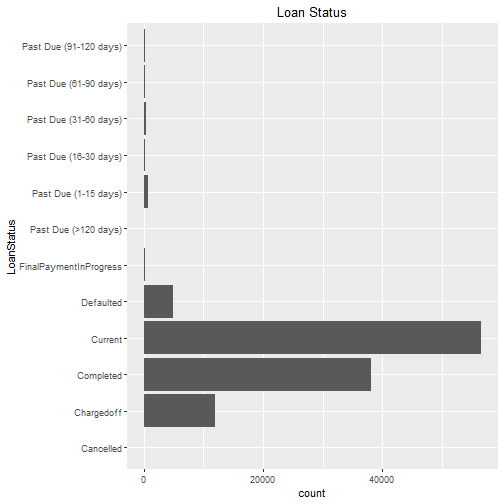

> In risk management one important job is to build a predictive model to predict whether the loan will be default or not. 'deliquent', 'default' and 'charge off' are terms helping investor to estimate whether or not they can expect to collect on the outstanding debt at all. According to the definition of deliquencies from [badcredit.org](https://www.badcredit.org/delinquencies-defaults-charge-offs-whats-difference/), an account will be considered severely deliquent if no payment has been received 60 days beyond the due date.Those deliquent accounts may have higher risk of default.

> So I created a new variable 'DelinquentBorrowers' using '0' to represent none deliquent borrowers and '1' to represent deliquent borroweres, including loans that are noted default, charged off, and past due over 60 days. According to [LendingClub](https://help.lendingclub.com/hc/en-us/articles/216127747-What-is-the-difference-between-a-loan-that-is-in-default-and-a-loan-that-has-been-charged-off-), In general, a note goes into Default status when it is 121 or more days past due. When a note is in Default status, Charge Off occurs no later than 150 days past due (i.e. No later than 30 days after the Default status is reached) when there is no reasonable expectation of sufficient payment to prevent the charge off.

### 2.1.3 Define deliquent borrower

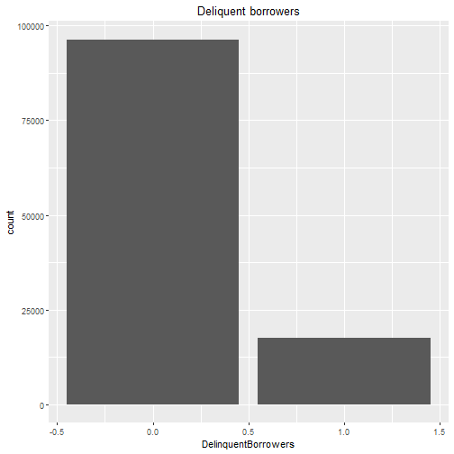

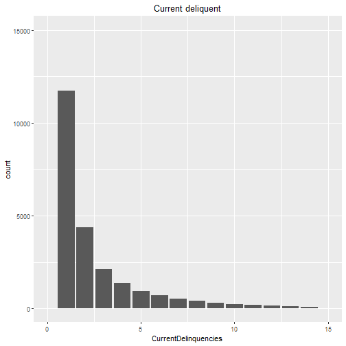

### 2.1.4 Borrower's credit score

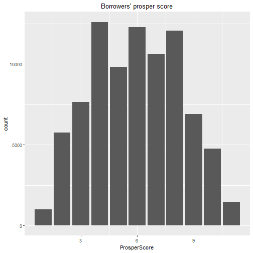

> People's credit score is similar to a normal distribution. Most people's credit score ranges between 4-8.

### 2.1.5 Borrower's interest rate

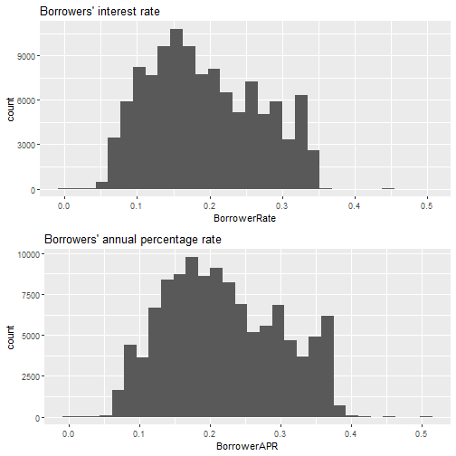

> Borrower's APR and interest are similar, but APR is slightly higher than interest rate because APR is the combination of the nominal interest rate and any other costs or fees involved in procuring the loan, according to [Investopedia](https://www.investopedia.com/terms/a/apr.asp)

### 2.1.6 Loan purpose

> The loan categories are give as numerical variables, in order to investigate the correlation of loan purpose with other features, the 'ListingCategory' column was coverted into categorical variable.

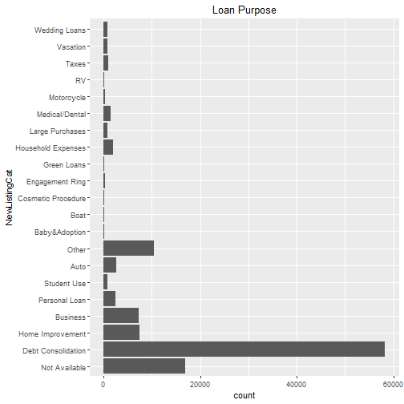

> Debt Consolidation is the main purpose of the loan. So next we can explore the available bank credit and number of loans of the borrowers.

### 2.1.7 Borrower's other loans

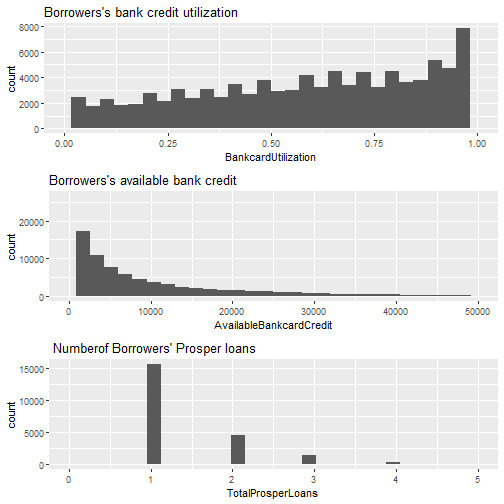

> Some people may have used most of their bank credit because they only have very small amount of available credit, or some people may only have use less than 10 % of their bank credit because their available credit is large. Most people only have one prosper loan. they might borrow money from prosper loan for some extrem situation. We can dig into those in later session.

### 2.1.8 Home ownership

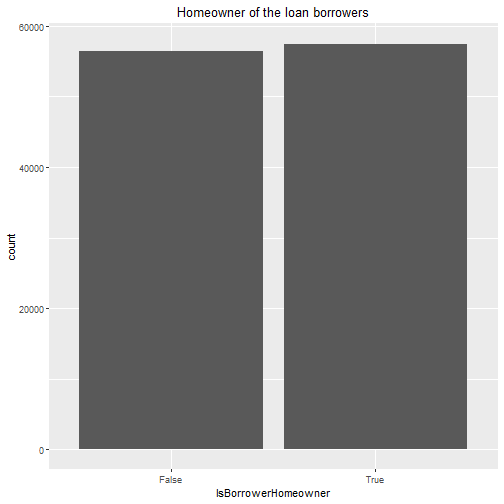

> Half of the borrowers are home owner. Unfortunatly, the chart of loan purpose does not contain mortgage, but only home improvement. So we have no clue if the loan is for the purpose of mortgage. In later session we can look at how the home owership affects the loan status.

### 2.1.9 Borrowers' income

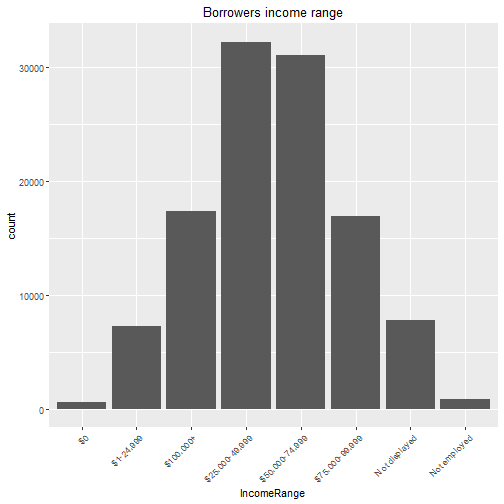

> People with income range 25,000-50,000 top Borrowers.

### 2.1.10 Debt to income ratio

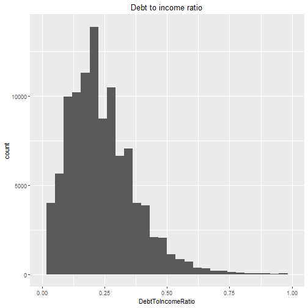

### 2.1.11 Prosper Loan Amount

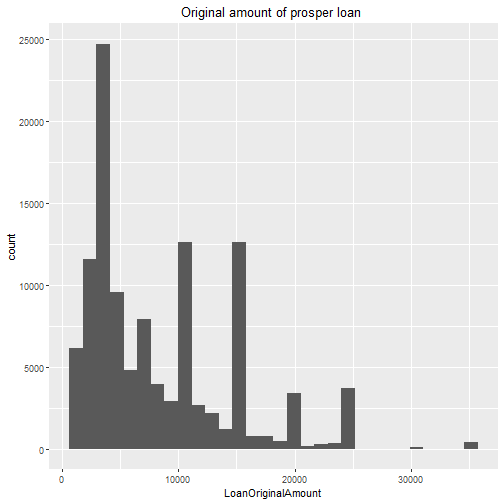

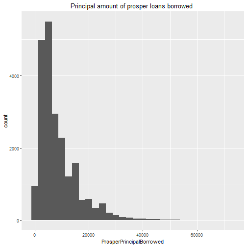

### 2.1.12 Employment status

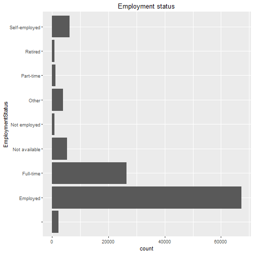

### 2.1.13 Loan volume issued by time

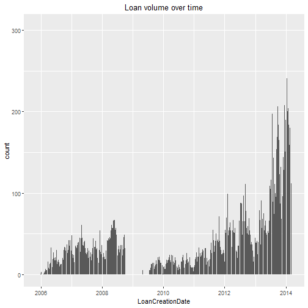

> From 2005 to 2014, the number of Prosper loans incresed over time. except the 2009, maybe the data for 2009 is missing.

## 2.2 Univariate Analysis

### What is the structure of your dataset?

> There are 113937 observations of 81 variables. Data types including 'factor', 'num', and'int. Variables are about loan information and borrowers' information

### What is/are the main feature(s) of interest in your dataset?

> From an investors's perspective, they would be interested in any features that might predict the risk of default from the borrowers. Those features could be the purpose of the loan, loan amont, loan status, the employment status, the borrowers' creadit score,the borrowers's income range, the number ofloans they have, the debt to income ratio, the number of account deliquent.

### What other features in the dataset do you think will help support your investigation into your feature(s) of interest?

> To study the borrower interest rate and loan status, I included ListingCreationDate, bank credit utilization, AvailableBankcardCredit, StatedMonthlyIncome and DebtToIncomeRatio.The borrower state could be intesting feature to explore because the average income varies from state to state. The homeowner might have higher risk of default, the employment status, employment status duration could also tell if the borrowers are able to pay off the loan ontime.

### Did you create any new variables from existing variables in the dataset?

> In order to investigate the loan amount over time. I created a new column named 'LoanCreationDate' in the format of '%m/%d/%Y'. Also, to investigate the purpose of the loan, I created a new column named 'NewLisingCat' to convert the numerical category of loan into categorical variables. Another new column named DelinquentBorrowers is also created to categorize the deliquent and none deliquent loans.

### Of the features you investigated, were there any unusual distributions?

> For the debt to income ratio, there is an outlier at ratio 10.01, which does not make sense. Also the column name of ListingCreationDate is weired, so I renamed the column name.

# Bivariate Plots Section

### 2.3.1 Scatterplot matrices

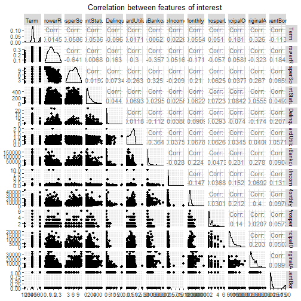

> I expected that there would be a strong correlation between Prosper score, borrower rate, deliquent borrower,monthly income. I dont't see such trends, but there is median correlation between borrower rate and prosper socre.

### 2.3.2 Interest rate over time

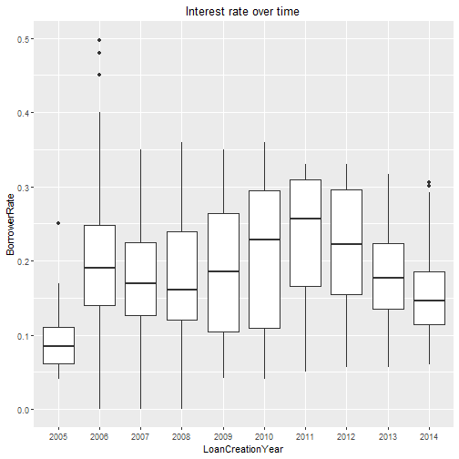

> The yearly borrower rate varies year by year, there is no increasing or decreasing trend over time.

### 2.3.3 Loan amount change over time.

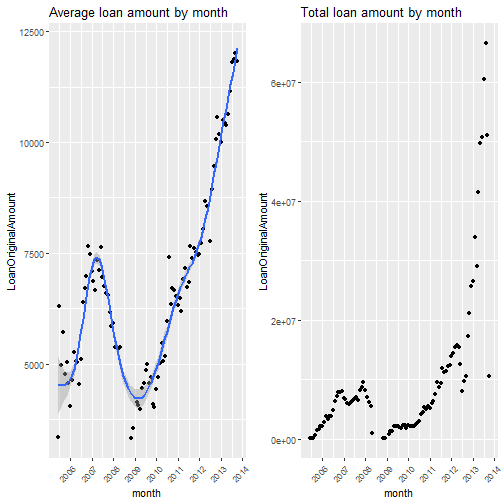

> In the univariate analysis session, we know that the loan volume increased by years, so it make sense that the total amount of loan increases over time. The average loan amount also tells an sharp increase of loan amount since 2009. Maybe because Prosper became more and more popular.

### 2.3.4 Loan amount vs. loan purpose

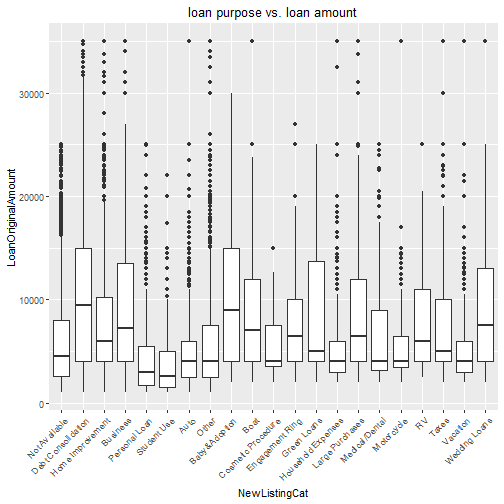

> People borrow large amount of loan for debt consolidation, baby&adoption and wedding.

### 2.3.5 Loan amount vs employment status

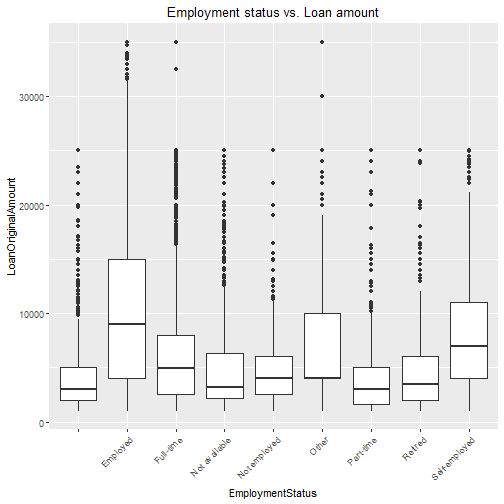

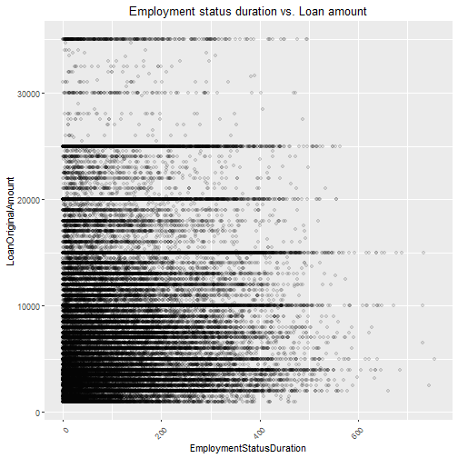

> People who borrower higher amount of loan are employed. For those people whoes loans are below 10000 tend to have shorter employment duration.

### 2.3.6 Credit score vs.Monthly income

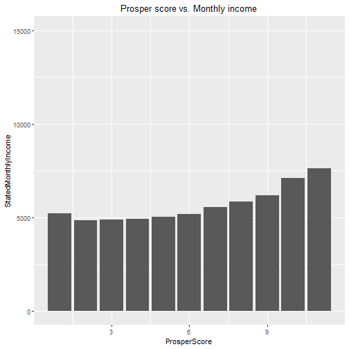

> By average, people with higer monthly income have higher credit rating on Prosper loan.

### 2.3.7 Debt-to-income ratio vs. Monthly income

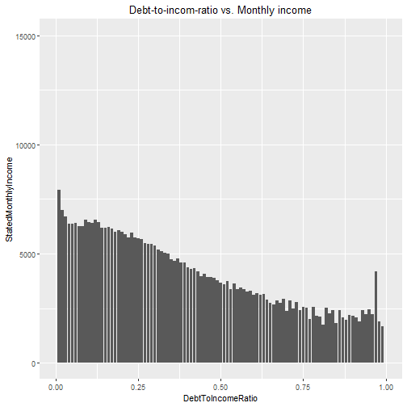

> By average, people with higer monthly income have lower debt-to-income ratio on Prosper loan.

### 2.3.8 Borrower Rate vs. Loan Amount

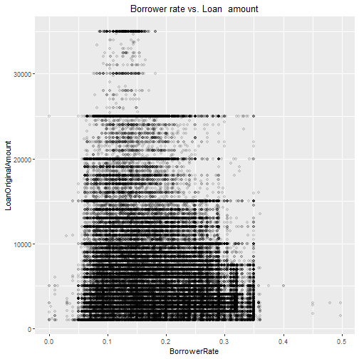

> There is no trend that higher loan amount would have higher interest rate.

### 2.3.9 Debt-to-income ratio vs. Loan amount

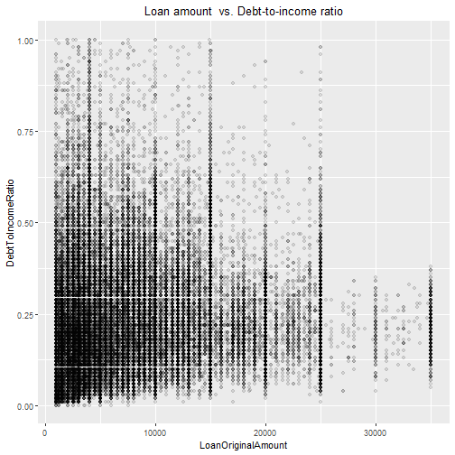

> Again there is no trend indicate that higher debt to income ratio would borrow more money.

### 2.3.10 Geographical distribution of loans

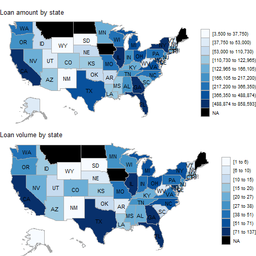

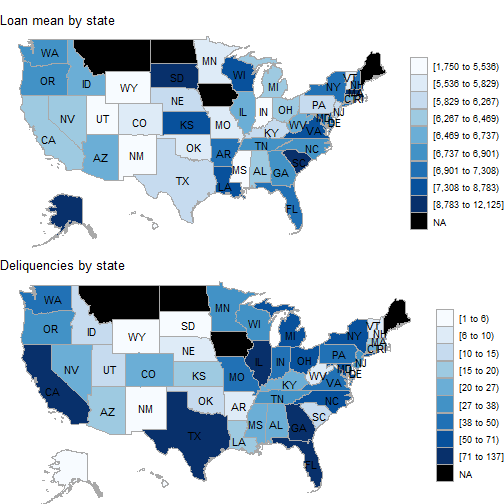

> From a geographical perspective California, Texas, New York, Florida and Illinois have the largest dollar amounts and volumes of loans. The deliquent loans is geographically consistent with the high volume and large amount of the loan. But the average loan amount is higher in states Alaska and South Carolina

# Bivariate Analysis

# Multivariate Plots Section

### 2.4.1 Homeownership vs. Loan amount

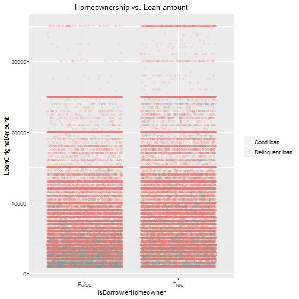

> There is no big difference for deliquent borrowers if they are home ower or not.

### 2.4.2 Monthly income vs. Loan amount

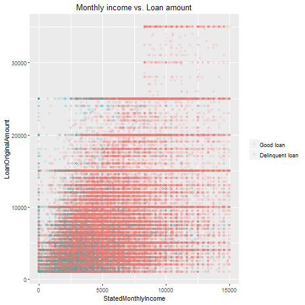

> Deliquent borrower tend to have lower montly income. Interestingly, lower income borowers tend to have lower loan amount, and People with higher income tend to borrow more money.

### 2.4.3 Monthly income vs. Prosper score

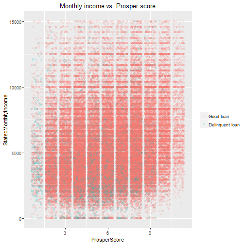

> In the Bivariable analysis session, I found that Borrower with higher income have higher Prosper score. This is consistent with this plot that deliquent borrowers have lower income. But deliquent borrowers are not always those with lower Prosper score.

### 2.4.4 Prosper score vs. Borrower rate

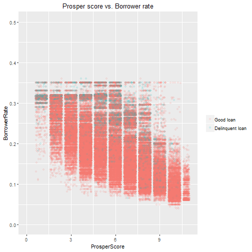

> Deliquent Borrower tend to have higher borrower rate. While higher Prosper rating borrowers have lower borrower rate. So high borrower rate might cause deliquency, then deliquency could lower the borrower's credit score. We can investigate this further.

### 2.4.5 Loan purpose vs. Monthly income

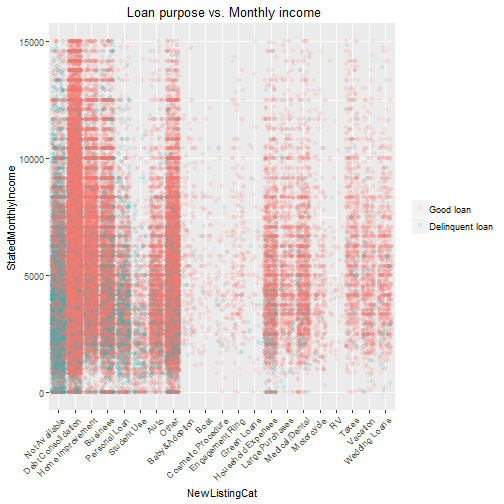

> Borrowers for business, personal loan, and student use have very high deliquent loans. Unfortunately, the loan purpose for borrower with highest deliquencies are not available.